# 03 · Volcanoes

Protein volcanoes with the enriched pathways ringed

These were drawn in `01_Gene_Sets` when this repo had no pathway test, which meant handing `enrichVolcano` an empty enrichment table and overriding the check that refuses one. Now that `01_` runs fgsea there is a real table to pass, the package is called as written, and the override is gone.

Fold change runs along x and −log10 of the raw p-value up y. Point colours and the count badges read protein-level BH FDR; the ring reads set-level fgsea FDR. The two are separate claims on one figure, and the ring is the weaker of them — `02_Set_Tests` is where the set p-value you would quote comes from.

```r
library(here)
library(dplyr)
library(tibble)
library(purrr)
library(ggplot2)
here::i_am("03_Pathway_Enrichment/03_Volcanoes/a_script/03_volcanoes.qmd")
```

```
here() starts at /Users/dtl0018/Desktop/A_Proteomics_Analysis/2026/BFR/BFR_limpa
```

```r
source(here("03_Pathway_Enrichment", "00_Functions", "00_functions.R"))

stage <- here("03_Pathway_Enrichment", "03_Volcanoes")
figure_dir <- file.path(stage, "b_reports", "figures")
dir.create(figure_dir, recursive = TRUE, showWarnings = FALSE)

inputs <- stage_inputs(
  pathway = "03_Pathway_Enrichment/01_Gene_Sets/c_data/pathway_inputs.rds",
  design = "02_Differential_Expression/01_Design/c_data/design.rds"
)
pathway <- inputs$pathway
d <- inputs$design

protein_results <- pathway$protein_results
fgsea_results <- filter(pathway$fgsea_results, collection == params$collection)
training_contrasts <- c("BFR_post_vs_pre", "HLRT_post_vs_pre")
stopifnot(nrow(fgsea_results) > 0, !is.null(protein_results$label))

# volcano_ring() matches leading-edge genes against the point labels, and a label carries its
# accession when the symbol appears on more than one protein. Translate the edges into label
# space or the tick lines silently draw nothing.
gene_to_label <- with(
  filter(protein_results, contrast == contrast[1], !is.na(gene)),
  set_names(label, gene)
)
fgsea_results$leadingEdge <- map(fgsea_results$leadingEdge, \(genes) {
  unname(gene_to_label[genes[genes %in% names(gene_to_label)]])
})

plot_theme <- enrichVolcano::volcano_ring_theme(
  base_size = 12, base_family = "sans", palette = "okabe", ns = "#777777"
)
contrast_titles <- c(
  BFR_post_vs_pre = "BFR: post vs pre",
  HLRT_post_vs_pre = "High load: post vs pre",
  BFR_vs_HLRT_at_T1 = "BFR vs high load: pre-training control",
  BFR_vs_HLRT_at_T2 = "BFR vs high load: post-training",
  interaction = "Interaction: difference in training responses"
)
count(fgsea_results, contrast, significant = padj < params$set_fdr)
```

| contrast | significant | n |
| --- | --- | --- |
| BFR_post_vs_pre | FALSE | 894 |
| BFR_post_vs_pre | TRUE | 105 |
| BFR_vs_HLRT_at_T1 | FALSE | 998 |
| BFR_vs_HLRT_at_T1 | TRUE | 1 |
| BFR_vs_HLRT_at_T2 | FALSE | 940 |
| BFR_vs_HLRT_at_T2 | TRUE | 59 |
| HLRT_post_vs_pre | FALSE | 939 |
| HLRT_post_vs_pre | TRUE | 60 |
| interaction | FALSE | 997 |
| interaction | TRUE | 2 |

```r
make_volcano <- function(contrast, rank_by = "fdr") {
  points <- filter(protein_results, .data$contrast == .env$contrast)
  ring <- fgsea_results |>
    filter(.data$contrast == .env$contrast, padj < params$set_fdr) |>
    slice_min(padj, n = params$ring_n) |>
    mutate(pathway = sub("^[^|]*\\|", "", pathway))
  if (rank_by == "pi") {
    labels <- points |>
      arrange(desc(pi_value), protein) |>
      slice_head(n = params$label_n) |>
      pull(label)
    subtitle <- "Labels ranked by pi-value; colours and counts use BH FDR"
  } else {
    labels <- points |>
      filter(fdr_significant) |>
      arrange(padj, P.Value, protein) |>
      slice_head(n = params$label_n) |>
      pull(label)
    subtitle <- paste0("Protein significance: BH FDR < ", params$protein_fdr)
  }
  enrichVolcano::volcano_ring(
    volc_df = select(points, label, logFC, plot_p, padj),
    enrich_df = ring,
    gene_col = "label", pval_col = "plot_p", padj_col = "padj",
    volc_sig_col = "padj", genes_col = "leadingEdge",
    p_threshold = params$protein_fdr, logfc_threshold = 0,
    title = unname(contrast_titles[contrast]), subtitle = subtitle,
    label_mode = if (length(labels)) "by_genes" else "none",
    label_genes = labels, label_n = params$label_n,
    label_size = 3.1, axis_size = 3.1, count_size = 3.3,
    point_size = 1.2, theme = plot_theme
  ) +
    theme(
      plot.title = element_text(size = 13, face = "bold"),
      plot.subtitle = element_text(size = 10, face = "plain"),
      plot.margin = margin(8, 8, 8, 8)
    )
}
save_volcano <- function(volcano, name) {
  for (extension in c("png", "pdf")) {
    ggsave(file.path(figure_dir, paste0(name, ".", extension)),
      plot = volcano, width = 7, height = 6.5, units = "in", dpi = 300,
      bg = "white"
    )
  }
}
```

## By FDR

A ringed pathway is one fgsea called significant on this contrast, and the ticks mark its leading-edge proteins. The control panel is the one to read first: rings there are what the test produces on a comparison that cannot contain signal.

**BFR vs high load: pre-training control**

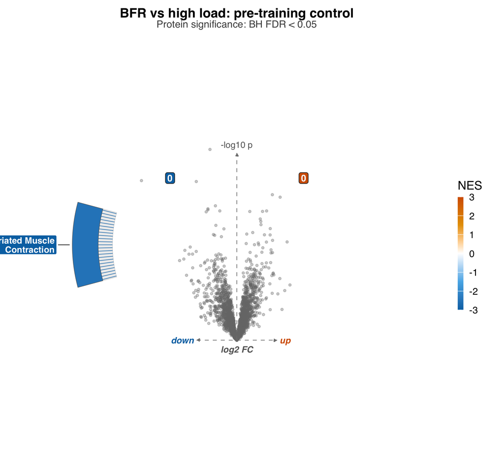

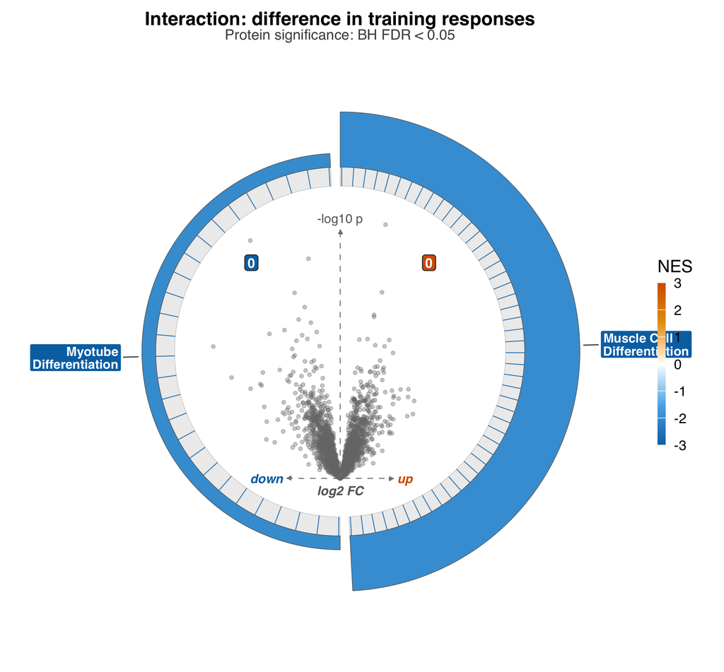

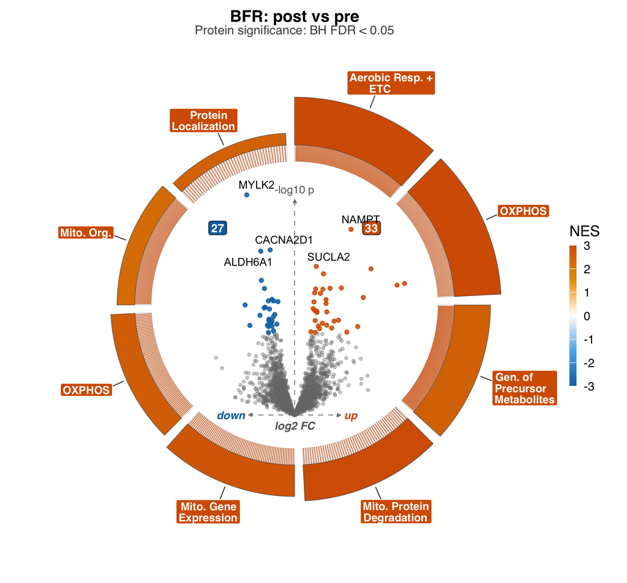

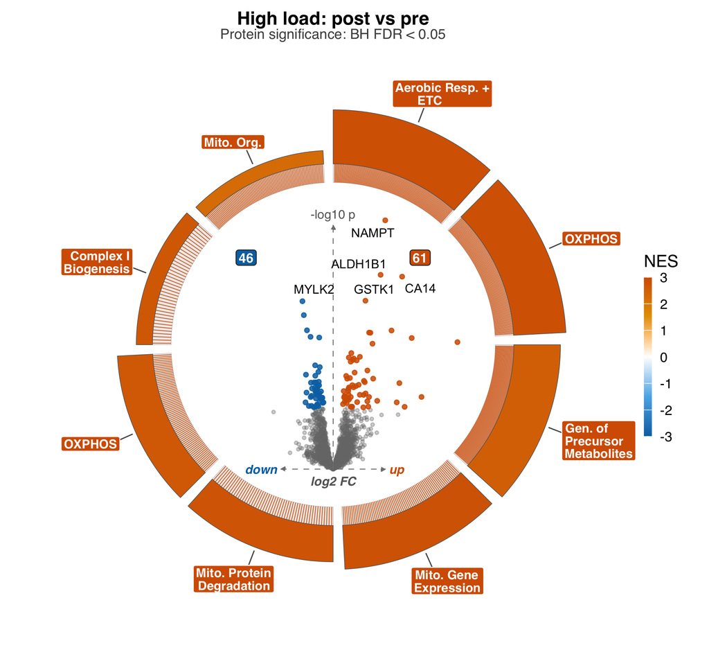

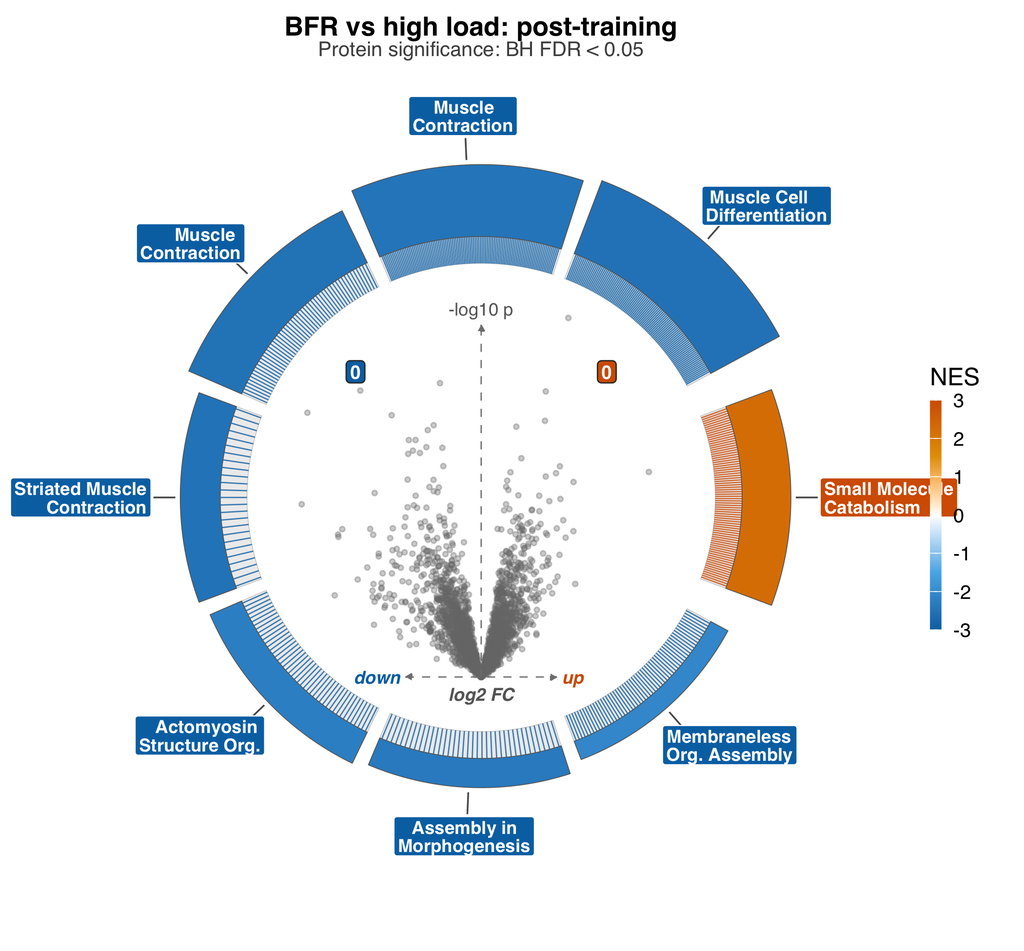

## The same plots, ranked by pi

Same points, same colours, same rings. Only the labels move: the top 5 proteins by pi-value are named whether or not they pass FDR. A pi label ranks a protein and selects nothing, so nothing named here has been discovered.

**BFR: post vs pre**

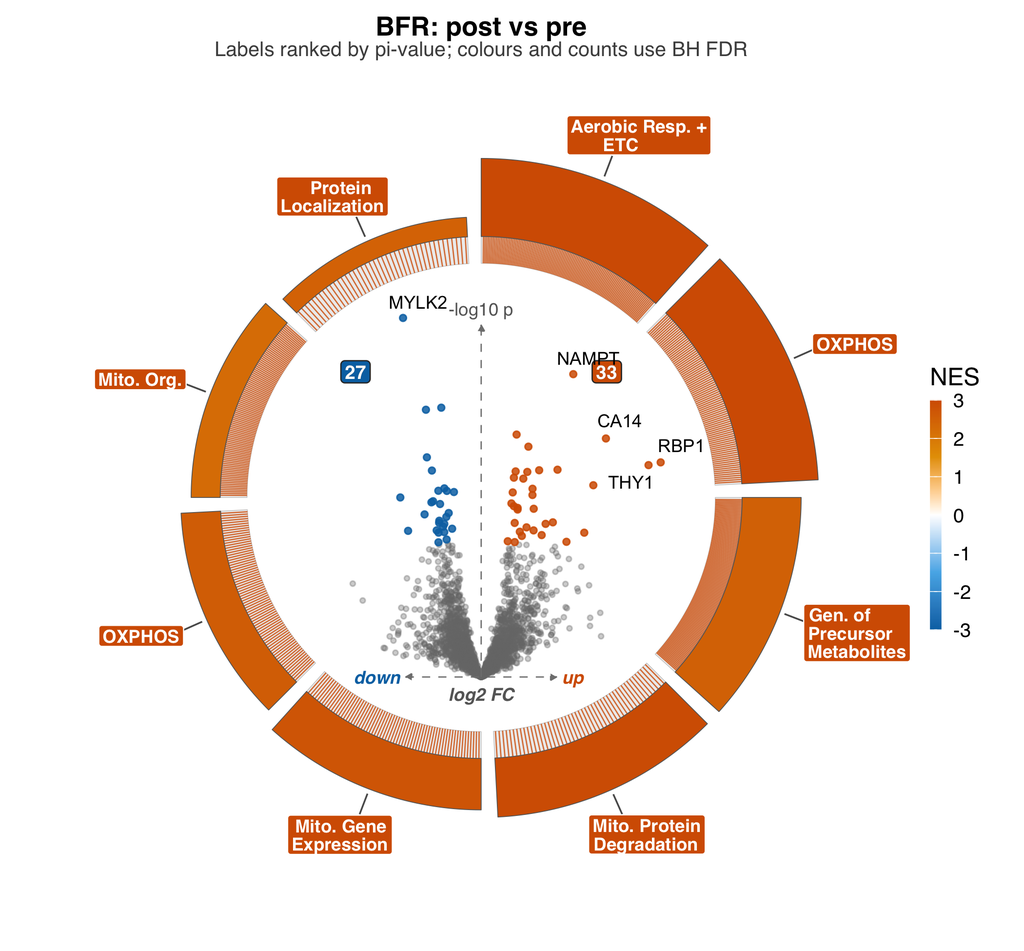

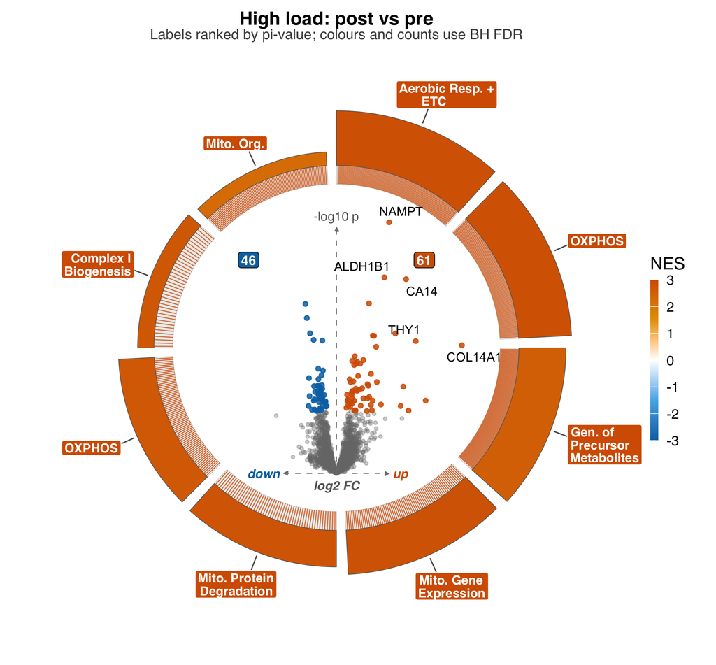

## What was drawn

```r
tibble(file = sort(basename(list.files(figure_dir, pattern = "\\.png$"))))
```

| file |
| --- |
| protein_volcano_fdr_BFR_post_vs_pre.png |
| protein_volcano_fdr_BFR_vs_HLRT_at_T1.png |
| protein_volcano_fdr_BFR_vs_HLRT_at_T2.png |
| protein_volcano_fdr_HLRT_post_vs_pre.png |
| protein_volcano_fdr_interaction.png |
| protein_volcano_pi_rank_BFR_post_vs_pre.png |
| protein_volcano_pi_rank_HLRT_post_vs_pre.png |